# Linear Models and Their Generalizations

Chapter 3- Part 3: ANCOVA single-factor model

Katia Meziani

# Motivation

In many situations, the set of explanatory variables includes both quantitative and qualitative variables. Up to now, we have discussed methods that handle either quantitative or qualitative variables separately. However, since both cases originate from the linear model, it is possible to combine them—this is known as analysis of covariance (ANCOVA). Here, we will focus on a simple example involving one categorical factor and one quantitative variable. The extension of this approach will be explored in practice.

## Intima media dataset

We will work throughout this chapter with the Intima Media dataset.

**Atherosclerosis** is the leading cause of death for men over 35 and women over 45 in most developed countries. It manifests as a thickening and loss of elasticity in the inner walls of the arteries, leading to conditions like myocardial infarction. The arterial wall consists of three layers: the intima, media, and adventitia. **The thickness of the intima-media layer** is a recognized **marker of atherosclerosis**. This measurement was taken ultrasonically from a sample of 110 subjects in 1999 at the Bordeaux University Hospital.

```r
library(dbplyr)
marqueur<-read.csv("Intima_Media1.csv")
marqueur$tabac=as.factor(marqueur$tabac)
marqueur$alcool=as.factor(marqueur$alcool)
marqueur$SEXE=as.factor(marqueur$SEXE)
marqueur%>%rmarkdown::paged_table()
```

| SEXE | AGE | taille | poids | tabac | mesure | alcool |
| --- | --- | --- | --- | --- | --- | --- |
| H | 33 | 170 | 70 | OccS | 0.52 | OccD |
| F | 33 | 177 | 67 | RegS | 0.42 | OccD |
| F | 53 | 164 | 63 | OccS | 0.65 | NoD |
| F | 42 | 169 | 76 | OccS | 0.48 | OccD |
| F | 53 | 152 | 54 | NoS | 0.45 | OccD |
| F | 50 | 162 | 53 | RegS | 0.49 | OccD |
| H | 22 | 181 | 72 | NoS | 0.42 | OccD |
| F | 26 | 162 | 61 | OccS | 0.45 | OccD |
| H | 50 | 170 | 80 | NoS | 0.65 | RegD |
| F | 47 | 178 | 73 | NoS | 0.52 | OccD |

[output cut: 100 more lines]

**We want to conduct an analysis of the influence of the regressor `Age`and `alcool` on the thickness of the intima-media.**

**Ⓡ** **Example: Dataset Intima Media**

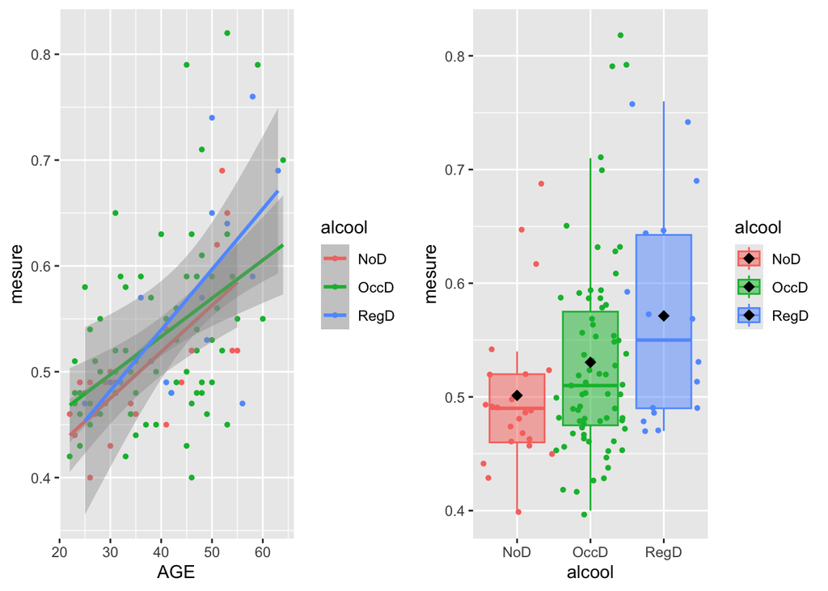

📈 These plot suggest that there seems to be an impact of the regressor `Age` and the factor `alcool` on the variable `measure`.

# 1. ANCOVA single-factor model

When the response variable $Y$ is explained by regressors and one factor, we refer to the model as an **ANCOVA single-factor model**. In this context, we are modeling a quantitative dependent variable $Y$ based on a qualitative explanatory variable (or factor) that has $J \in \mathbb{N}^*$ distinct categories or levels and regressor $x$. We denote by

- $Y_{ij}$ the $i$-th observation that corresponds to the $j$-th modality of the factor.
- $x_{ij}$ the value of the regressor of the $i$-th observation having modality $j$.
- $n_{j}$ the number of observations $Y_{ij}$ associated with the modality $j$ $s.t.$:
  $$\sum_{j=1}^Jn_{j}=n.$$

📌 The results derived from this model can be easily generalized to ANCOVA models involving three factors, four factors, and so on.

**[The plan]** Let denote by $\mathcal{J}=\{1,\cdots,J\}$ and by $\mathcal{K}=\{1,\cdots,K\}$. The plan is said to be

- Complete if $\forall (j,k)\in\mathcal{J}\times\mathcal{K}$, $n_{jk}\geq 1$,
- Imcomplete if $\exists (j,k)\in\mathcal{J}\times\mathcal{K}$, $n_{jk}=0$,
- Balanced if $\forall (j,k)\in\mathcal{J}\times\mathcal{K}$, $n_{jk}=I=\frac{n}{JK}$.

**Ⓡ** **Example: Dataset Intima Media**

```r
Plan_alcool <- as.data.frame(table(marqueur$alcool))
colnames(Plan_alcool) <- c("alcool", "Counts")
Plan_alcool %>%kableExtra::kbl() %>%kableExtra::kable_styling()
```

| alcool | Counts |
| --- | --- |
| NoD | 23 |
| OccD | 71 |
| RegD | 16 |

📈 The plan is complete and unbalanced

## 1.1. Regular Model

| Modality 1 | ⋯ | Modality $J$ |
| --- | --- | --- |
| $Y_{i1} = \tau_1 + \beta_1 x_{i1} + \epsilon_{i1}$ | ⋯ | $Y_{iJ} = \tau_J + \beta_J x_{iJ}+ \epsilon_{iJ}$ |

**[Regular Model]**
We define the **linear Gaussian regression model (ANCOVA single-factor model)** in its regular form as follows:
$$\begin{equation*}
\label{eq:Anova1_RM}
\tag{Anova1 [RM]}
Y_{ij}=\tau_j + \beta_1 x_{ij}+\epsilon{ij},\quad i\in\{1,\ldots,n_j\},
\ j\in\mathcal{J}
\end{equation*}$$
where $\epsilon_{ij}\stackrel{i.i.d.}{\sim}\mathcal{N}(0,\sigma^2).$

📌 **Note**:

- This assumption can be checked as explained in the previous chapter.
- We assume that the regression line varies across the different groups (modalities), meaning that both the intercept $\tau_j$ and the slope $\beta_j$ change depending on the group $j$.

Let’s now express our standard single-factor ANCOVA model in matrix form. To do this, we first define for all $j \in \mathcal{J}$ the vectors $\boldsymbol{Y}^j \in \mathbb{R}^{n_j}$, $\,\boldsymbol{\epsilon}^j \in \mathbb{R}^{n_j}$, $\,\boldsymbol{\theta}^j \in \mathbb{R}^2$ and the matrices $\boldsymbol{X}^j$ of size $n_j\times 2$ such that:
$$\boldsymbol{Y}^j =
\begin{pmatrix}
Y_{1j} \\
\vdots\\
Y_{n_jj}
\end{pmatrix},\qquad
\boldsymbol{\epsilon}^j =
\begin{pmatrix}
\epsilon_{1j} \\
\vdots\\
\epsilon_{n_jj}
\end{pmatrix},\qquad
\boldsymbol{\theta}^j = \begin{pmatrix}
\tau_j \\
\beta_j
\end{pmatrix}\quad\text{and}\quad
\boldsymbol{X}^j = \begin{pmatrix}
1 & x_{1j} \\
\vdots & \vdots\\
1 & x_{n_{j}j}
\end{pmatrix}$$

We can now combine these into global vectors and matrices, defining the response vector $\boldsymbol{Y}\in \mathbb{R}^n$ the error vector $\boldsymbol{\epsilon}\in \mathbb{R}^n$ the unknown parameter vector $\boldsymbol{\theta}\in \mathbb{R}^{2J}$ and the design matrix $\boldsymbol{X}$ of size $n \times 2J$:

$$\boldsymbol{Y}=
\begin{pmatrix}
\boldsymbol{Y}^1 \\
\vdots\\
\boldsymbol{Y}^J
\end{pmatrix},\qquad
\boldsymbol{\epsilon}=
\begin{pmatrix}
\boldsymbol{\epsilon}^1 \\
\vdots\\
\boldsymbol{\epsilon}^J
\end{pmatrix},\qquad
\boldsymbol{\theta}= \begin{pmatrix}
\boldsymbol{\theta}^1 \\
\vdots\\
\boldsymbol{\theta}^J
\end{pmatrix}\quad\text{and}\quad \boldsymbol{X}= \begin{pmatrix}
\boldsymbol{X}^1 & \cdots & 0 \\
\vdots & \ddots & \vdots\\
0 & \cdots & \boldsymbol{X}^J
\end{pmatrix}$$

📌 **Note**: $\text{Rank}(\boldsymbol{X})=2J$ and $\text{Rank}(\boldsymbol{X}^j)=2$, $\forall j\in\mathcal{J}$,**indicating that $\boldsymbol{X}$ and $\boldsymbol{X}^j$ have full rank**.

Therefore, our model can be expressed as:

**[Regular Model]**
We define the **linear Gaussian regression model (ANCOVA single-factor model)** in its regular matrix form as follows:
$$\begin{equation}
\label{eq:ANcOVA1_RM}
\tag{ANcOVA 1 [RM]}
\boldsymbol{Y}=\boldsymbol{X}\boldsymbol{\theta}+\boldsymbol{\epsilon},
\end{equation}$$
where $\boldsymbol{\epsilon}\sim\mathcal{N}(\boldsymbol{0}_n,\sigma^2\mathbf{I}_n)$

Moreover
$$\begin{equation*}
\boldsymbol{Y}^j=\boldsymbol{X}^j\boldsymbol{\theta}^j+\boldsymbol{\epsilon}^j,
\end{equation*}$$
where $\boldsymbol{\epsilon}^j\sim\mathcal{N}(\boldsymbol{0}_{n_j},\sigma^2\mathbf{I}_{n_j})$, $\forall j\in\mathcal{J}$.

## 1.2. Singular Model

From the regular model $Y_{ij} = \tau_j + \beta_j x_{ij} + \epsilon_{ij}$, consider the following decomposition of $\tau_j + \beta_j x_{ij}$:
$$\forall\;j\in\mathcal{J},\quad \tau_j+ \beta_j
x_{ij}=(\mu + \alpha_j) + (b + c_j) x_{ij},$$
where:

- $\mu$: **the reference intercept** (overall mean or baseline intercept).
- $\mu + \alpha_j$: **the intercept of cell $j$**, with $\alpha_j$ representing the deviation of cell $j$’s intercept from the reference.
- $b$: **the reference slope** (baseline slope).
- $b + c_j$: **the slope for cell $j$**, where $c_j$ represents the deviation of cell $j$’s slope from the reference slope.

| Modality 1 | ⋯ | Modality $J$ |
| --- | --- | --- |
| $Y_{i1}=(\mu + \alpha_1) + (b + c_1) x_{i1}+\epsilon_{i1}$ | ⋯ | $Y_{iJ}=(\mu + \alpha_J) + (b + c_J) x_{iJ}+\epsilon_{iJ}$ |

📌 **Note**: In this decomposition:

- $(\alpha_j)_j$ represent **the main effects of the factor**, capturing how each cell’s intercept deviates from the reference.
- $(c_j x_{ij})_j$ represent **the interaction between the factor and the regressor**, where the slopes for each cell $j$ are allowed to vary by $c_j$.

**[Singular Model]**
We define the **linear Gaussian regression model (ANCOVA single-factor model)** in its singular form as follows:
$$\begin{equation*}
\label{eq:Anova1_SM}
\tag{Anova1 [SM]}
Y_{ij}=(\mu + \alpha_j) + (b + c_j) x_{ij}+\epsilon_{ij},\quad
i\in\{1,\ldots,n_j\}, \ j\in\mathcal{J}
\end{equation*}$$
where
$$\epsilon_{ij}\stackrel{i.i.d.}{\sim}\mathcal{N}(0,\sigma^2).$$

Now, let’s express our singular ANCOVA single-factor modelin matrix form. Define:

- $\boldsymbol{Y}\in\mathbb{R}^n$ and $\boldsymbol{\epsilon}\in\mathbb{R}^n$.
- $\forall j\in\mathcal{J}$, $\textbf{x}_{\cdot j}=(x_{1j},\cdots,x_{n_jj})^T\in\mathbb{R}^{n_j}$.
- $\textbf{c}=(c_1,\ldots,c_J)^\top\in\mathbb{R}^J$
- $\boldsymbol{\alpha}=(\alpha_1,\ldots,\alpha_J)^\top\in\mathbb{R}^J$
- $\textbf{x}\in\mathbb{R}^n$, $D_\textbf{x}\in\mathbb{R}^{n\times J}$, $A\in\mathbb{R}^{n\times J}$ matrix, by $\textbf{c}\in\mathbb{R}^J$ and $\boldsymbol{\alpha}\in\mathbb{R}^J$ $s.t.$

$$\textbf{x}=
\begin{pmatrix}
x_{\cdot 1} \\
\vdots\\
x_{\cdot J}
\end{pmatrix},\quad
D_\textbf{x}=\begin{pmatrix}
x_{\cdot 1} & 0 & & \\
0 & x_{\cdot 2}& & \vdots\\
\vdots & &\ddots&0\\
&&& x_{\cdot J}
\end{pmatrix},\quad
A=\begin{pmatrix}
{\Large{\mathbf{1}}}_{n_1} & 0 & & \\
0 & {\Large{\mathbf{1}}}_{n_2} & & \vdots\\
\vdots & &\ddots&0\\
&&& {\Large{\mathbf{1}}}_{n_J}
\end{pmatrix},$$

$$\mathbb{X}=[{\Large{\mathbf{1}}}_n \ A
\ \textbf{x}\
D_\textbf{x}]\in\mathbb{R}^{n\times(2+2J)}\quad\text{and}\quad\boldsymbol{\beta}=\begin{pmatrix}
\mu \\
\boldsymbol{\alpha}\\
b\\
\textbf{c}
\end{pmatrix}\in\mathbb{R}^{2J+2}$$

📌 **Note**: $\text{Rank}(\mathbb{X})=2J$, indicating that it does **not** have full rank.

**[Singular Model]**
We define the **linear Gaussian regression model (ANCOVA single-factor model)** in its singular matrix form as follows:
$$\begin{equation*}
\label{eq:ANCOVA1_SM}
\tag{ANCOVA1 [SM]}
\boldsymbol{Y}=\mu{\Large{\mathbf{1}}}_n+A\boldsymbol{\alpha}+
\textbf{x}b+D_\textbf{x}\textbf{c}+\boldsymbol{\epsilon}=\mathbb{X}\boldsymbol{\beta}+\boldsymbol{\epsilon}.
\end{equation*}$$
where $\boldsymbol{\epsilon}\sim\mathcal{N}(\boldsymbol{0}_n,\sigma^2\mathbf{I}_n)$

# 2. Estimation of the Model

**Regular Model (Full Rank Design Matrix)**

In the case where $\boldsymbol{X}$ is a full rank matrix, the estimation of the model parameters is defined as:
$$\widehat{\boldsymbol{\theta}} = \underset{\boldsymbol{\theta}\in
\mathbb{R}^{2J}}{\arg \min}
\|\boldsymbol{Y}-\boldsymbol{X}\boldsymbol{\theta}\|^2.$$
The parameter estimates are given by
$$\widehat{\boldsymbol{\theta}} = (\boldsymbol{X}^\top
\boldsymbol{X})^{-1} \boldsymbol{X}^\top \boldsymbol{Y},$$
which is unique due to the full rank of $\boldsymbol{X}$.

**Singular Model (Not Full Rank Design Matrix)**

When the design matrix $\mathbb{X}$ is **not** full rank, the estimation is given by:
$$\widehat{\boldsymbol{\beta}} \in \underset{\boldsymbol{\beta}\in
\mathbb{R}^{2J+2}}{\arg \min} \|\boldsymbol{Y}-
\mathbb{X}\boldsymbol{\beta}\|^2.$$

The parameter estimate $\widehat{\boldsymbol{\beta}}$ is **not unique** since $\mathbb{X}$ is not full rank. To obtain a unique solution, a constraint must be imposed:
$$2J+2 - \text{Rank}(\boldsymbol{X}) = 2J+2 - 2J = 2.$$

These constraints ensure that we can identify a specific solution among the infinite possibilities that arise due to the singularity of $\mathbb{X}$.

📌 **Note**: For both models, the prediction is unique and can be expressed as:

$$\widehat{\boldsymbol{Y}} = P_\boldsymbol{X}\boldsymbol{Y}=
\boldsymbol{X}\widehat{\boldsymbol{\theta}}, \quad
\widehat{\boldsymbol{Y}} = P_\mathbb{X}\boldsymbol{Y}=
\mathbb{X}\widehat{\boldsymbol{\beta}}.$$

## 2.1. The Classic used constraints

1.$\,$ **Contrast treatment.** The constraint by default is $\alpha_1=c_1= 0$.

**Ⓡ** `lm(mesure~alcool*AGE,data=marqueur)`

2.$\,$ For a fix $k>1$, $\alpha_k=c_k=0$ (choice of the cell $k$ as the reference cell), just adjust using the `relevel()` function.  
3.$\,$ **Contrast sum.** $\sum_{j=1}^J\alpha_j=\sum_{j=1}^Jc_j=0.$

**Ⓡ** `lm(mesure~alcool*AGE,contrasts=list(alcool="contr.sum"),data=marqueur)`

4.$\,$ **Orthogonality constraint.** $\sum_{j=1}^Jn_j\alpha_j=\sum_{j=1}^Jn_jc_j=0$ not coded in **Ⓡ** so we need to implement it ourselves.

## 2.2. Theoretical results

**Some notations**

| Empirical Mean | Definition |
| --- | --- |
| Of observations $Y_{ij}$ having the modality $j$ | $\overline{Y}_{\cdot j}=\frac{1}{n_j}\sum_{i=1}^{n_j}Y_{ij}$ |
| Of all observations $Y_{ij}$ | $\overline{Y}_{\cdot \cdot}=\frac{1}{n}\sum_{j=1}^J\sum_{i=1}^{n_j}Y_{ij}=\frac{1}{n}\sum_{j=1}^Jn_j\overline{Y}_{\cdot j}$ |
| Of all empirical means $\overline{Y}_{\cdot j}$ | $\overline{\overline{Y}}_{\cdot \cdot }=\frac{1}{J}\sum_{j=1}^J\overline{Y}_{\cdot j}$ |
| Of all the observations $x_{ij}$ | $\overline{x}_{\cdot j}=\frac{1}{n_j}\sum_{i=1}^{n_j}x_{ij}$ |
| Of order 2 of all the observations $x_{ij}$ | $\overline{x^2}_{\cdot j}=\frac{1}{n_j}\sum_{i=1}^{n_j}x_{ij}^2$ |
| Of the observations $(x_{ij},Y_{ij})$ | $\overline{x_{\cdot j}Y_{\cdot j}}=\frac{1}{n_j}\sum_{i=1}^{n_j}x_{ij}Y_{ij}$ |

**[Proposition 5]**  
Let $\mathcal{J} := \{1, \ldots, J\}$. Consider the linear Gaussian regression model (ANCOVA single-factor model) in its singular form. For the following constraints, the estimations are as follows

| Model | Constraints | Estimators |
| --- | --- | --- |
| Regular | No constraints | $\widehat\tau_j=\frac{\overline{x^2}_{\cdot j}\overline Y_{\cdot j}- \overline x_{\cdot j}\overline {x_{\cdot j}Y_{\cdot j}}}{\overline{x^2}_{\cdot j}-(\overline{x}_{\cdot j})^2}\,$ and $\,\widehat\be… |
| Singular | $\alpha_1=c_1=0$ | $\begin{cases} &\widehat\alpha_1=\widehat c_1=0\\ &\widehat \mu=\widehat\tau_1\\ &\widehat b=\widehat\beta_1 \end{cases}$ and $\,\,\forall j\geq 2$ $\begin{cases} &\widehat\alpha_j= \widehat\tau_j-\wi… |

📝 Here we will only give the case of constraint 1. For other constraints, a similar calculation is sufficient to find the result.

*Sketch of proof.* In the regular model, (OLSE) gives $\widehat{\boldsymbol{\theta}}=(\boldsymbol{X}^T\boldsymbol{X})^{-1}\boldsymbol{X}^T\boldsymbol{Y}$ as $\boldsymbol{X}$ is full rank. The $\boldsymbol{X}^j$ are full rank $2$ and $\boldsymbol{X}$ matrix is diagonal by block,then $\forall j\in \mathcal{J}$

$$\begin{eqnarray*}
\widehat{\boldsymbol{\theta}}_j & = & \begin{pmatrix}
\widehat\tau_j \\
\widehat\beta_j\\
\end{pmatrix}=\left((\boldsymbol{X}^j)^T\boldsymbol{X}^j\right)^{-1}(\boldsymbol{X}^j)^T\boldsymbol{Y}^j
\end{eqnarray*}$$

As $\widehat{Y}_{ij}$ is unique, it comes
$$\widehat Y_{ij}=\widehat \mu+\widehat\alpha_j+(\widehat b+\widehat
c_j)x_{ij}=\widehat\tau_j+\widehat\beta_jx_{ij}$$
The result is obtained using the constraint and by identification. $\square$

**Ⓡ** **Example: Dataset Intima Media**

**Implement Contrast treatment: $\alpha_1=c1=0$ (by default)**

```r
mod1<-lm(mesure~alcool*AGE, data=marqueur)#;mod1
summary(mod1)
```

```
##
## Call:
## lm(formula = mesure ~ alcool * AGE, data = marqueur)
##
## Residuals:
##       Min        1Q    Median        3Q       Max
## -0.160984 -0.050613 -0.004789  0.032264  0.239773
##
## Coefficients:
##                  Estimate Std. Error t value Pr(>|t|)
## (Intercept)     0.3434482  0.0520561   6.598 1.79e-09 ***
## alcoolOccD      0.0455390  0.0616409   0.739    0.462
## alcoolRegD     -0.0329522  0.0946437  -0.348    0.728
## AGE             0.0043849  0.0013830   3.171    0.002 **
## alcoolOccD:AGE -0.0007766  0.0016041  -0.484    0.629
## alcoolRegD:AGE  0.0013381  0.0021822   0.613    0.541
## ---
## Signif. codes:  0 '***' 0.001 '**' 0.01 '*' 0.05 '.' 0.1 ' ' 1
##
## Residual standard error: 0.07292 on 104 degrees of freedom
## Multiple R-squared:  0.3244, Adjusted R-squared:  0.2919
## F-statistic: 9.988 on 5 and 104 DF,  p-value: 7.962e-08
```

**Unbiased estimator of $\sigma^2$**

**[Proposition 2]**

Consider the linear Gaussian regression model (ANCOVA single-factor model) in its singular form under the posutlats **[P1]–[P3]**. For any classical constraint, an unbiased estimator of $\sigma^2$ is
$$\widehat\sigma^2=\frac{\|\boldsymbol{Y}-\widehat{\boldsymbol{Y}}\|^2}{n-2J}=\frac{1}{n-2J}\sum_{j=1}^J\sum_{i=1}^{n_j}(Y_{ij}-
\widehat{Y}_{ij})^2,$$
where $\widehat{\boldsymbol{Y}}=P_\boldsymbol{X}\boldsymbol{Y}=P_\mathbb{X}\boldsymbol{Y}$

Moreover, under the gaussian assumption **[P4]**
$$\frac{(n-2J)\widehat\sigma^2}{\sigma^2}\sim\chi^2(n-2J).$$

*Proof.* Immediate according to previous Chapters.$\square$

📌 **Note**: Whether we consider the regular or the singular model, we have the equality of ranks:
$$\text{Rank}(\boldsymbol{X}) = \text{Rank}(\mathbb{X}) = 2J.$$

# 3. Tests

Let us define the different following models:

- $\mathcal{M}_{\mu}\,:\, Y=\mu{\Large{\mathbf{1}}}_n+\epsilon$
- $\mathcal{M}_{\mu,\alpha}\,:\, Y=\mu{\Large{\mathbf{1}}}_n+A\boldsymbol{\alpha}+\epsilon$
- $\mathcal{M}_{\mu,b}\,:\, Y=\mu{\Large{\mathbf{1}}}_n+b\textbf{x}+\epsilon$
- $\mathcal{M}_{\mu,\alpha,b}\,:\, Y=\mu{\Large{\mathbf{1}}}_n+A\boldsymbol{\alpha}+bx+\epsilon$
- $\mathcal{M}_{\mu,b,c}\,:\, Y=\mu{\Large{\mathbf{1}}}_n+b\textbf{x}+D_\textbf{x}c+\epsilon$
- $\mathcal{M}_{\mu,\alpha,b,c}\,:\, Y=\mu{\Large{\mathbf{1}}}_n+A\boldsymbol{\alpha}+b\textbf{x}+D_\textbf{x}c+\epsilon$

where $\boldsymbol{\epsilon}\sim\mathcal{N}(0_n,\sigma^2\mathbf{I}_n)$.

**Type I Analysis.** Here, the full model is represented by $\mathcal{M}_{\mu,\alpha,b,c}$. The line-by-line tests conducted in the `anova` analysis are
$$R_j^a =\{F_{j}^a>q^{ {\Large{\mathcal{F}}}_{d_j,n-2J}
}_{1-\alpha}\},\quad \text{for}\quad j=1,\ldots,3$$

and are summarized in the following table:

| `anova` | Tests | `F Value` | Fisher law |
| --- | --- | --- | --- |
| **Line 1.** | $\mathcal{H}_0 : \mathcal{M}_{\mu} \,\,\,\,\,\,\,\, vs \,\, \mathcal{H}_1 : \mathcal{M}_{\mu,\alpha}$ | $F_{1}^a=\\|P_{[{\Large{\mathbf{1}}}_n \ A]}Y-P_{1_n}Y\\|^2/((J-1)\widehat\sigma^2)$ | ${\Large{\mathcal{F}}}_{J-1,n-2J}$ |
| **Line 2.** | $\mathcal{H}_0 : \mathcal{M}_{\mu,\alpha} \,\,\,\, vs \,\, \mathcal{H}_1 : \mathcal{M}_{\mu,\alpha,b}$ | $F_{2}^a=\\|P_{[{\Large{\mathbf{1}}}_n \ A \ \,\textbf{x}]}Y-P_{[{\Large{\mathbf{1}}}_n \ A]}Y\\|^2/\widehat{\sigma}^2$ | ${\Large{\mathcal{F}}}_{1,n-2J}$ |
| **Line 3.** | $\mathcal{H}_0 : \mathcal{M}_{\mu,\alpha,b} \,\, vs \,\, \mathcal{H}_1 : \mathcal{M}_{\mu,\alpha,b,c}$ | $F_{3}^a=\\|P_{[\mathbb{X}]}Y-P_{[{\Large{\mathbf{1}}}_n \ A \ \,\textbf{x}]}Y\\|^2/((J-1)(K-1)\widehat\sigma^2)$ | ${\Large{\mathcal{F}}}_{J-1,n-2J}$ |

📌 **Note**: Recall, $\widehat\sigma^2$ is calculated from the full model., i.e. here from $\mathcal{M}_{\mu,\alpha,b,c}$, $s.t.$
$$\widehat\sigma^2=\frac{\|\boldsymbol{Y}-P_{\mathbb{X}}\boldsymbol{Y}\|^2}{n-2J}$$

*Sketch of proof.*

First note that:

$\begin{array}{ll} &\text{Rank}(\mathbb{X})= \text{Rank}([{\Large{\mathbf{1}}}_n \ A \ \textbf{x}\ D_\textbf{x}])=2J\\ &\text{Rank}({\Large{\mathbf{1}}}_n)=1\\ &\text{Rank}([1_n \ A])=J\\ &\text{Rank}([{\Large{\mathbf{1}}}_n \ \,\textbf{x}])=2\\ &\text{Rank}([{\Large{\mathbf{1}}}_n \ A \ \,\textbf{x}])=J+1 \end{array}$

Moreover,

$\begin{array}{ll} &\text{Rank}(\mathbb{X})-\text{Rank}([{\Large{\mathbf{1}}}_n \ A \ \,\textbf{x}])=2J-(J+1)=J-1\\ &\text{Rank}([{\Large{\mathbf{1}}}_n \ A \ \,\textbf{x})-\text{Rank}( [{\Large{\mathbf{1}}}_n \ A])=(J+1)-J=1\\ &\text{Rank}([{\Large{\mathbf{1}}}_n \ A \ \,\textbf{x}])-\text{Rank}([1_n \ \,\textbf{x}])=(J+1)-2=J-1\\ &\text{Rank}([{\Large{\mathbf{1}}}_n \ A])-\text{Rank}({\Large{\mathbf{1}}}_n)=J-1 \end{array}$

Recall that by proposition 4
$$\frac{(n-2J)\widehat\sigma^2}{\sigma^2}\sim\chi^2(n-2J).$$

Then, we conclude by the *Nested* theorem of the chapter 2.$\square$

**Ⓡ** **Example: Dataset Intima Media**

```r
mod_full<-lm(mesure~alcool*AGE, data=marqueur)
anova(mod_full)
```

|  | Df | Sum Sq | Mean Sq | F value | Pr(>F) |
| --- | --- | --- | --- | --- | --- |
| alcool | 2 | 0.046168625 | 0.023084312 | 4.3416902 | 1.545328e-02 |
| AGE | 1 | 0.212280806 | 0.212280806 | 39.9257073 | 6.656793e-09 |
| alcool:AGE | 2 | 0.007085276 | 0.003542638 | 0.6662983 | 5.157848e-01 |
| Residuals | 104 | 0.552957112 | 0.005316895 | NA | NA |

📈 Both `alcool` and `AGE` have a significant effect on the target `mesure`. But what happens if we change the order of the regressor and the factor?

```r
mod_full_2<-lm(mesure~AGE*alcool, data=marqueur)
anova(mod_full_2)
```

|  | Df | Sum Sq | Mean Sq | F value | Pr(>F) |
| --- | --- | --- | --- | --- | --- |
| AGE | 1 | 0.249729341 | 0.249729341 | 46.9690161 | 5.258179e-10 |
| alcool | 2 | 0.008720089 | 0.004360045 | 0.8200358 | 4.432430e-01 |
| AGE:alcool | 2 | 0.007085276 | 0.003542638 | 0.6662983 | 5.157848e-01 |
| Residuals | 104 | 0.552957112 | 0.005316895 | NA | NA |

**Type II Analysis.** The line-by-line tests conducted in the `Anova` analysis are
$$R_j^A =\{F_{j}^A>q^{ {\Large{\mathcal{F}}}_{d_j,n-2J}
}_{1-\alpha}\},\quad \text{for}\quad j=1,\ldots,3$$

and are summarized in the following table:

| `Anova` | Tests | `F Value` | Fisher law |
| --- | --- | --- | --- |
| **Line 1.** | $\mathcal{H}_0 : \mathcal{M}_{\mu,b} \,\,\,\,\, vs \,\, \mathcal{H}_1 : \mathcal{M}_{\mu,\alpha,b}$ | $F_{1}^A=\\|P_{[{\Large{\mathbf{1}}}_n \ A \ \,\textbf{x}]}Y-P_{[{\Large{\mathbf{1}}}_n \ \, \textbf{x}]}Y\\|^2/((J-1)\widehat\sigma^2)$ | ${\Large{\mathcal{F}}}_{J-1,n-2J}$ |
| **Line 2.** | $\mathcal{H}_0 : \mathcal{M}_{\mu,\alpha} \,\,\,\, vs \,\, \mathcal{H}_1 : \mathcal{M}_{\mu,\alpha,b\beta}$ | $F_{2}^A=\\|P_{[{\Large{\mathbf{1}}}_n \ A \ \,\textbf{x}]}Y-P_{[{\Large{\mathbf{1}}}_n \ A]}Y\\|^2/\widehat{\sigma}^2$ | ${\Large{\mathcal{F}}}_{1,n-2J}$ |
| **Line 3.** | $\mathcal{H}_0 : \mathcal{M}_{\mu,\alpha,b} \,\, vs \,\, \mathcal{H}_1 : \mathcal{M}_{\mu,\alpha,b,c}$ | $F_{3}^A=\\|P_{[\mathbb{X}]}Y-P_{[{\Large{\mathbf{1}}}_n \ A \ \,\textbf{x}]}Y\\|^2/((J-1)(K-1)\widehat\sigma^2)$ | ${\Large{\mathcal{F}}}_{J-1,n-2J}$ |

**Ⓡ** **Example: Dataset Intima Media**

```r
library(car)
Anova(mod_full)
```

|  | Sum Sq | Df | F value | Pr(>F) |
| --- | --- | --- | --- | --- |
| alcool | 0.008720089 | 2 | 0.8200358 | 4.432430e-01 |
| AGE | 0.212280806 | 1 | 39.9257073 | 6.656793e-09 |
| alcool:AGE | 0.007085276 | 2 | 0.6662983 | 5.157848e-01 |
| Residuals | 0.552957112 | 104 | NA | NA |

📈 The regressor `AGE` has a strong impact and the factor `acool`is less significant. The interaction is not significant (`Pr(>F)`>5%).

# 4. What about the full dataset ?

In this section, we will analyze the entire dataset by comparing various models using multiple approaches. The goal is to evaluate which model provides the best fit for the data when considering all available predictors: `alcool`, `tabac`, `SEXE`, `AGE`, `taille`, and `poids`. We begin by fitting two linear models: one with just the intercept (null model: `MOD0`) and another with all predictors included (`MOD1`).

```r
MOD0<-lm(mesure~1,data=marqueur)
MOD1<-lm(mesure~alcool+tabac+ SEXE+AGE+taille+poids,data=marqueur)
```

**Model selection using stepwise AIC** To find the most relevant predictors, we apply stepwise selection using AIC (Akaike Information Criterion). This process helps to identify a simpler model that still explains the data well. We’ll perform both forward and backward selection methods and compare the selected models.

```r
library(MASS)
modBoth<-stepAIC(MOD0, mesure~SEXE+AGE+taille+poids+tabac+alcool,trace=F, direction=c("both"))
#modForw<-stepAIC(MOD0, mesure~SEXE+AGE+taille+poids+tabac+alcool,trace=F, direction=c('forward'))
#modBack<-stepAIC(MOD1,~.,trace=F,direction=c("backward"))
# Anova(MOD1)
modBoth
```

```
##
## Call:
## lm(formula = mesure ~ AGE + poids, data = marqueur)
##
## Coefficients:
## (Intercept)          AGE        poids
##    0.246151     0.004378     0.001643
```

**Analysis of variance (ANOVA) with Type I approach** In the next step, we use Type I Analysisto understand the sequential contribution of each factor to the model.

```r
anova(MOD1)
```

|  | Df | Sum Sq | Mean Sq | F value | Pr(>F) |
| --- | --- | --- | --- | --- | --- |
| alcool | 2 | 0.046168625 | 0.023084312 | 4.628162 | 1.193582e-02 |
| tabac | 2 | 0.026552305 | 0.013276153 | 2.661729 | 7.472401e-02 |
| SEXE | 1 | 0.007858377 | 0.007858377 | 1.575522 | 2.123033e-01 |
| AGE | 1 | 0.198836347 | 0.198836347 | 39.864596 | 7.352620e-09 |
| taille | 1 | 0.001891969 | 0.001891969 | 0.379320 | 5.393529e-01 |
| poids | 1 | 0.033417123 | 0.033417123 | 6.699782 | 1.106362e-02 |
| Residuals | 101 | 0.503767072 | 0.004987793 | NA | NA |

📈 If we prioritize `alcool` as the first factor,it will show its importance in relation to other predictors.

**Model comparison** We now compare three models using Fisher tests for nested models:

1. The model selected via stepwise AIC (`modBoth`)
2. A model based on `alcool`, `AGE`, and `poids` as predictors (`MODanova`)
3. The full model with all predictors (`MOD1`)

```r
MODanova <- lm(mesure ~ alcool + AGE + poids, data = marqueur)
Comparaison<-c("modBoth vs MODanova","modBoth vs MODanova")
P_value<-c(anova(modBoth, MODanova)$`Pr(>F)`[2] ,anova(modBoth,MOD1)$`Pr(>F)`[2])
cbind.data.frame(Comparaison,P_value)
```

| Comparaison | P_value |
| --- | --- |
| modBoth vs MODanova | 0.8594191 |
| modBoth vs MODanova | 0.8756919 |

Finally, we extract the AIC values for the models to evaluate which one offers the best trade-off between model complexity and fit.

```r
AIC(modBoth, MODanova, MOD1)
```

|  | df | AIC |
| --- | --- | --- |
| modBoth | 4 | -269.7062 |
| MODanova | 6 | -266.0236 |
| MOD1 | 10 | -260.3069 |

📈 The model chosen as the best fit for the data is `modBoth`.

**Final Selected Model**: `modBoth` Let’s take a detailed look at the coefficients, standard errors, and statistical significance of each predictor in this final model:

```r
summary(modBoth)
```

```
##
## Call:
## lm(formula = mesure ~ AGE + poids, data = marqueur)
##
## Residuals:
##       Min        1Q    Median        3Q       Max
## -0.165827 -0.042764 -0.007056  0.032385  0.259679
##
## Coefficients:
##              Estimate Std. Error t value Pr(>|t|)
## (Intercept) 0.2461513  0.0424070   5.805 6.67e-08 ***
## AGE         0.0043776  0.0005966   7.338 4.43e-11 ***
## poids       0.0016432  0.0004958   3.314  0.00126 **
## ---
## Signif. codes:  0 '***' 0.001 '**' 0.01 '*' 0.05 '.' 0.1 ' ' 1
##
## Residual standard error: 0.06943 on 107 degrees of freedom
## Multiple R-squared:  0.3698, Adjusted R-squared:  0.358
## F-statistic: 31.39 on 2 and 107 DF,  p-value: 1.872e-11
```

📈 The final model demonstrates that `AGE` is the most significant predictor, followed by `poids`, in explaining the variation in mesure. The model explains around 36% of the variance in mesure, which suggests a reasonable fit. The overall `p-value: 1.872e-11` for the model is very low, confirming that the model is statistically significant.

**Diagnostic Plots for Model**

To evaluate the fit and assumptions of the final selected model, we can generate diagnostic plots.

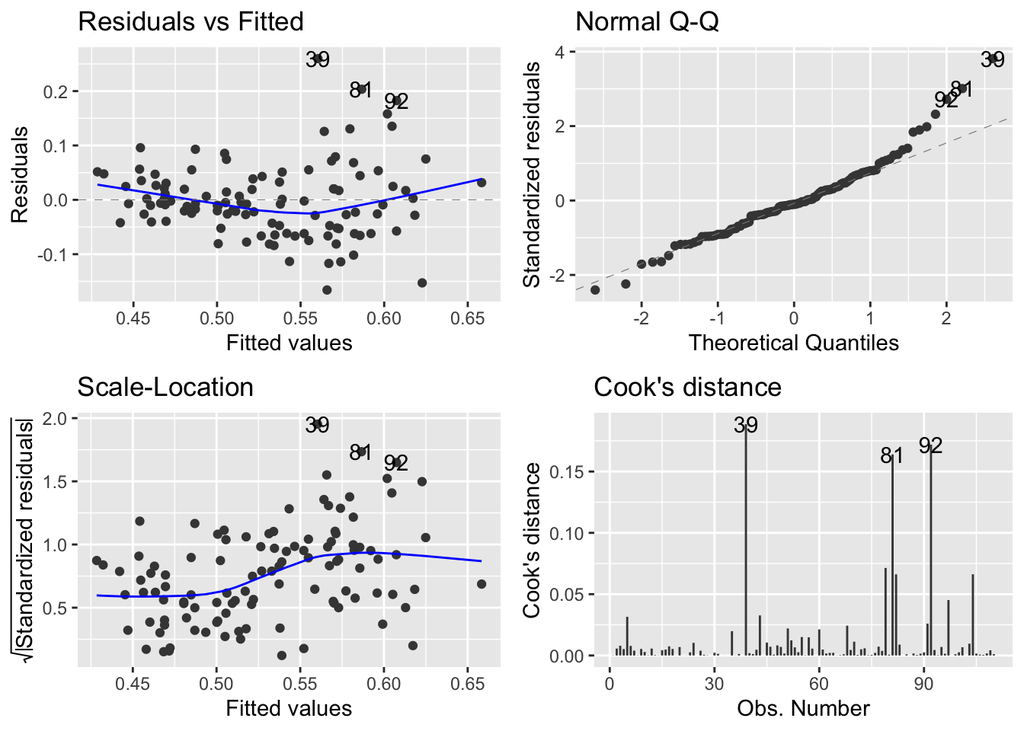

```r
library(ggfortify)
autoplot(modBoth,1:4)
```